# 201701194-최호진

Hojin Choe

2020 12 19

# 1.

“canadian.txt”는 캐나다 각 도시의 월별 평균 기온자료이다. 다음 명령문을 이용하여 자료를 불러들여올 수 있다. data=read.table(“canadian.txt”,header=TRUE,sep=")

```r
require(tidyverse)
```

## a.

개체수와 변수의 갯수를 밝히고 마지막 region 변수를 factor 로 변환하시오. (region 변수는 각 도시를 지리학적으로 분류한 것이다.)

```r
getwd()
```

```
## [1] "C:/r-project/R-stat-package/docs/Homework1"
```

```r
data <- read.table("C:/r-project/R-stat-package/data/canadian.txt", header=TRUE, sep="\t")
str(data)
```

```
## 'data.frame':    35 obs. of  13 variables:
##  $ Jan   : num  -4.65 -6.16 -5.72 -3.22 -8.11 ...
##  $ Feb   : num  -5.33 -6.18 -6.8 -3.49 -8.26 ...
##  $ Mar   : num  -2.532 -1.739 -2.935 0.152 -3.442 ...
##  $ Apr   : num  1.26 3.62 1.85 4.69 2.32 ...
##  $ May   : num  5.79 9.44 7.5 9.34 8.76 ...
##  $ Jun   : num  10.8 14.8 13.1 13.4 14.4 ...
##  $ Jul   : num  15.2 18.4 17.5 16.3 18.3 ...
##  $ Aug   : num  15.3 18.2 17.6 16.6 18 ...
##  $ Sep   : num  11.6 13.9 13.3 13.6 13.4 ...
##  $ Oct   : num  7.02 8.49 8.27 9.25 8.03 ...
##  $ Nov   : num  2.95 3.24 3.53 4.9 2.57 ...
##  $ Dec   : num  -1.845 -2.987 -2.029 -0.465 -4.152 ...
##  $ region: chr  "Atlantic" "Atlantic" "Atlantic" "Atlantic" ...
```

```r
data %>%
  mutate(region = factor(region))
```

```
##            Jan        Feb         Mar         Apr         May        Jun
## 1   -4.6548387  -5.325000  -2.5322581   1.2566667   5.7935484 10.7866667
## 2   -6.1580645  -6.182143  -1.7387097   3.6233333   9.4419355 14.7766667
## 3   -5.7225806  -6.796429  -2.9354839   1.8500000   7.4967742 13.1400000
## 4   -3.2161290  -3.489286   0.1516129   4.6866667   9.3419355 13.4033333
## 5   -8.1129032  -8.260714  -3.4419355   2.3166667   8.7580645 14.4433333
## 6   -9.9225806  -8.739286  -2.5870968   4.0600000  10.7870968 16.2066667
## 7  -23.7129032 -22.375000 -15.8806452  -7.3500000   0.9096774  8.2333333
## 8  -15.3580645 -13.232143  -5.8225806   2.9500000  10.1967742 16.0033333
## 9  -16.2354839 -14.303571  -6.5903226   2.2666667   9.3290323 15.3733333
## 10 -12.7806452 -11.278571  -4.6741935   3.2933333  10.9096774 16.3800000
## 11 -11.8161290 -10.653571  -4.0354839   3.9266667  10.7903226 15.4900000
## 12 -10.5322581  -9.057143  -2.5129032   5.7233333  12.9935484 18.0400000
## 13 -11.0838710  -9.417857  -2.8290323   5.6333333  12.9258064 17.9733333
## 14  -6.8064516  -6.100000  -0.7903226   6.1566667  12.4000000 17.4966667
```

[output cut: 93 more lines]

## b.

이 자료에 대해 중간값 다듬기를 진행하고, 모수의 추정치를 밝히시오. (교재 7 장 참고)

```r
med.data <- medpolish(data[,-13])
```

```
## 1: 1019.183
## 2: 985.0738
## Final: 984.4551
```

## c.

가법모형이 적절한지 그래프를 통해 판단하시오.

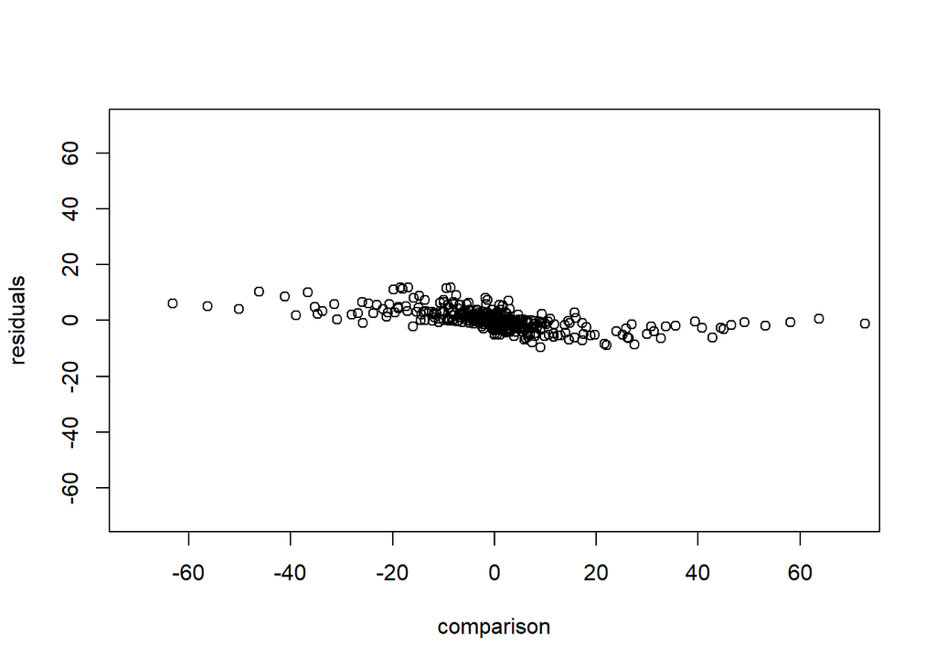

```r
attach(med.data)
comparison <- matrix(row, ncol = 1) %*% matrix(col, nrow = 1)/overall
plot(residuals ~ comparison, xlim = c(-70, 70), ylim = c(-70, 70))
```

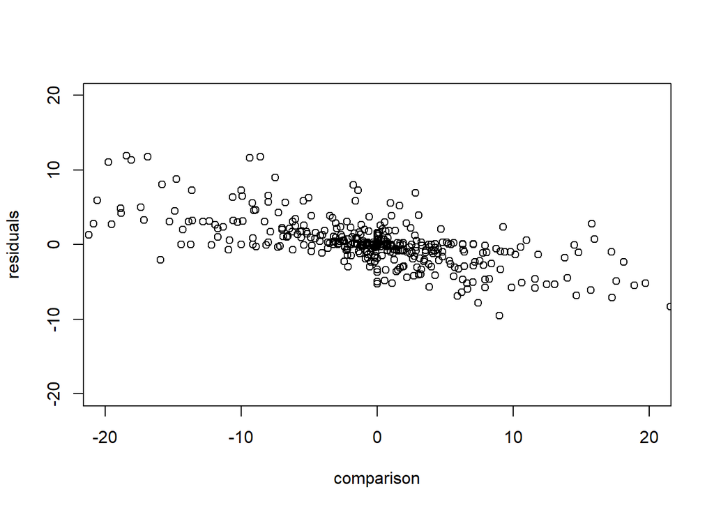

```r
plot(residuals ~ comparison, xlim = c(-20, 20), ylim = c(-20, 20))
```

```r
detach(med.data)
```

비교값 대 잔차의 산점도를 보면 “비교값 > 0” 인경우 “잔차 < 0” 이고 “비교값 < 0” 인경우 “잔차 > 0” 인 경향이 있음을 볼 수 있다. 이것은 가법적 모형이 타당하지 않음을 말한다. 따라서 가법적 모형은 적절하지 않다고 볼 수 있다.

## d.

중간값 다듬기 후 잔차를 계산하여 그로부터 각 도시가 갖는 기온의 특징을 기술하시오.

```r
med.data$residuals
```

```
##                    Jan         Feb         Mar         Apr         May
## St. Johns    7.9720161  5.82673963  1.99725806 -2.27620967 -4.79991935
## Halifax      4.6116398  3.11244623  0.93365591 -1.76669355 -3.00868279
## Sydney       5.6301344  3.08117127  0.31989247 -2.95701613 -4.37083333
## Yarmouth     7.3128226  5.56455069  2.58322581 -0.94411290 -3.34943548
## Charlottvl   3.4263710  1.80344470  0.00000000 -2.30379032 -2.92298387
## Fredericton  1.7155376  1.42371736  0.95368280 -0.46161290 -0.79510753
## Scheffervll -2.0752957 -2.21250768 -2.34037634 -1.87212366 -0.67303763
## Arvida      -2.3345161 -1.68370968 -0.89637097 -0.18618279  0.00000000
## Bagottville -2.2892204 -1.83242320 -0.74139785  0.05319893  0.05497312
## Quebec      -0.3098118 -0.28285331 -0.30069893 -0.39556452  0.16018817
## Sherbrooke   0.4758064  0.16324885  0.15911290  0.05887097 -0.13806451
## Montreal     0.0000000  0.00000000 -0.07798387  0.09586022  0.30548388
## Ottawa      -0.2753226 -0.08442396 -0.11782258  0.28215054  0.51403226
## Toronto      3.1250269  2.35636329  1.04381720 -0.07158602 -0.88884409
## London       3.0643817  2.12659370  1.11543011 -0.04040323 -0.74303764
## Thunderbay  -1.0765323 -0.15072581  0.24225806  0.50513441 -0.19685484
## Winnipeg    -5.2460484 -3.34466589 -1.81758064  0.73357527  1.55620969
## The Pas     -5.7522043 -3.31038403 -2.18825269  0.00000000  1.09198925
## Churchill   -2.6616936 -2.70201613 -3.89774194 -2.03282258  0.02766129
## Regina      -2.9427151 -0.75677036 -0.19811828  1.61432796  1.80470430
## Pr. Albert  -4.5883065 -2.16641705 -1.20822581  1.78325269  2.36233871
## Uranium Cty -8.3303763 -5.21125192 -4.59223118 -0.08634409  2.24607527
## Edmonton     0.3039785  2.10305684  1.20018817  2.05510753  1.53849463
## Calgary      3.8962366  5.58056835  3.00212365  1.45833333 -0.11118280
## Kamloops     4.4960753  7.26450845  5.75034946  2.65989247  0.29510753
## Vancouver   11.0304839 11.31792627  6.33314516  0.83021505 -2.89629033
## Victoria    11.9002150 11.80182796  6.53513441  0.74435484 -3.22333333
## Pr. George   3.9704301  6.93310292  5.23760752  2.55467742  0.25010753
## Pr. Rupert  11.6265054 11.76233487  6.28400538  0.22129032 -4.06478494
## Whitehorse  -0.9798925  2.76619048  2.38405914  1.84252688  0.98043011
## Dawson      -8.7444355 -5.15088710 -1.03209677  2.85497312  4.63524194
## Yellowknife -6.5041935 -4.78864055 -4.86604839 -0.98349462  3.24000000
## Iqaluit     -0.6825538 -3.24430492 -6.35731183 -5.67368279 -2.06416666
## Inuvik      -0.7824731 -1.95712750 -3.95400538 -2.12317204  4.21978495
## Resolute     0.9208333 -1.18723119 -6.03456989 -6.42137097 -0.90271505
##                      Jun         Jul          Aug          Sep          Oct
## St. Johns   -5.167983863 -3.63196237 -2.040887094 -0.729086024  0.740349465
## Halifax     -3.035134404 -2.31491936 -0.975456986 -0.342903225  0.354166666
## Sydney      -4.088790320 -2.62545700 -0.960188172 -0.319892471  0.721048387
```

[output cut: 53 more lines]

```
## Pr. Albert  -4.18889785 -5.1623656
## Uranium Cty -5.03516129 -7.1173387
## Edmonton    -3.10704301 -1.1926613
## Calgary     -1.46715054  1.8512097
## Kamloops    -0.90225807  2.6349194
## Vancouver    2.18806451  8.0790054
## Victoria     2.53887097  8.7971237
## Pr. George  -0.95413979  2.2028226
## Pr. Rupert   2.86913978  9.0266398
## Whitehorse  -4.22962365 -1.7249194
## Dawson      -9.55051075 -8.8313978
## Yellowknife -5.10231183 -6.0814785
## Iqaluit      0.74416667 -0.3404839
## Inuvik      -5.47532258 -1.7823387
## Resolute    -2.98018817  0.6822581
```

# 2.

perform.txt 라는 자료는 학생들의 수학(math)과 쓰기(writing) 점수를 기록한 것이다. 성별(gender), 인종(race.ethnicity), 부모의 교육 수준(parental.level.of.education), 점심 식사 종류(lunch: standard 는 정상 가격, free/reduced 는 공짜 또는 할인된 가격의 점심), 시험 준비 정도(test.preparation.course)와 같은 학생의 배경 정보가 같이 포함되어 있다. 괄호 안에 각 변수의 변수명이 기재되어 있다.

## a.

표와 그래프를 통해 이 대학에 지원한 학생들의 성별과 시험 준비 정도가 어떻게 분포하는지 알아보고 특징을 기술하시오.

```r
perform <- read.table("C:/r-project/R-stat-package/data/perform.txt", header = T)
glimpse(perform)
```

```
## Rows: 1,000
## Columns: 7
## $ math                        <int> 72, 69, 90, 47, 76, 71, 88, 40, 64, 38,...
## $ writing                     <dbl> 2677.722, 4701.506, 5745.832, 1133.634,...
## $ gender                      <chr> "female", "female", "female", "male", "...
## $ race.ethnicity              <chr> "group B", "group C", "group B", "group...
## $ parental.level.of.education <chr> "bachelor's degree", "some college", "m...
## $ lunch                       <chr> "standard", "standard", "standard", "fr...
## $ test.preparation.course     <chr> "none", "completed", "none", "none", "n...
```

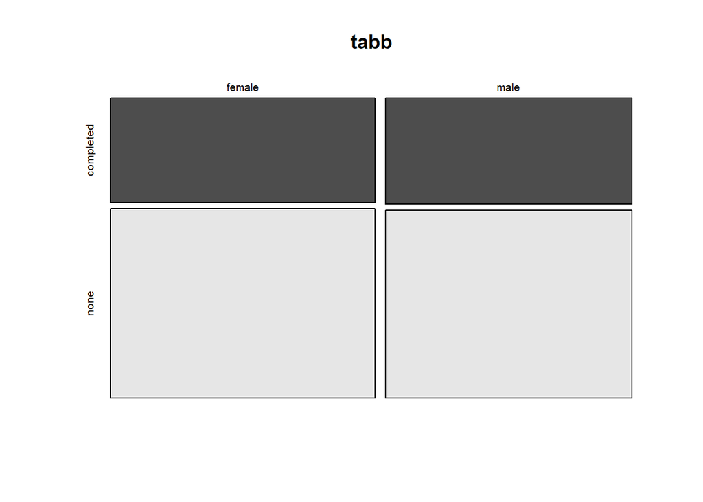

```r
tabb <- table(perform$gender, perform$test.preparation.course)
mosaicplot(tabb, color = T)
```

## b.

한 대학에서는 수학 점수가 80 점이상이고 쓰기 점수가 4000 점 이상인 학생을 신입생으로 선발한다. 시험 준비 정도에 따라 합격여부가 어떻게 달라지는지 상대도수를 이용하여 빈도표와 막대그림을 그려보고 현상을 기술하시오.

```r
idx1 <- perform$math >= 80
idx2 <- perform$writing >= 4000
perform_1 <- perform %>%
  mutate(Admit = idx1&idx2)
glimpse(perform_1)
```

```
## Rows: 1,000
## Columns: 8
## $ math                        <int> 72, 69, 90, 47, 76, 71, 88, 40, 64, 38,...
## $ writing                     <dbl> 2677.722, 4701.506, 5745.832, 1133.634,...
## $ gender                      <chr> "female", "female", "female", "male", "...
## $ race.ethnicity              <chr> "group B", "group C", "group B", "group...
## $ parental.level.of.education <chr> "bachelor's degree", "some college", "m...
## $ lunch                       <chr> "standard", "standard", "standard", "fr...
## $ test.preparation.course     <chr> "none", "completed", "none", "none", "n...
## $ Admit                       <lgl> FALSE, FALSE, TRUE, FALSE, FALSE, FALSE...
```

```r
prop.table(table(perform_1$test.preparation.course, perform_1$Admit), margin = 1)
```

```
##
##                  FALSE       TRUE
##   completed 0.84357542 0.15642458
##   none      0.94080997 0.05919003
```

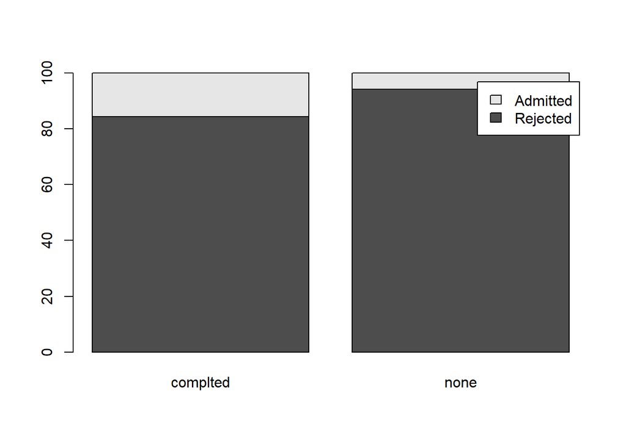

```r
tab <- table(perform_1$test.preparation.course, perform_1$Admit)
colnames(tab) <- c("Rejected", "Admitted")

tab.row <- apply(tab, 1, sum)
tab.r <- diag(1/tab.row) %*% tab *100
colnames(tab.r) <- c("Rejected", "Admitted")
rownames(tab.r) <- c("complted", "none")
barplot(t(tab.r), legend = colnames(tab.r))
```

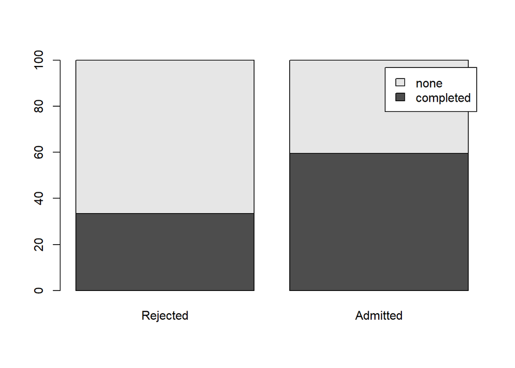

```r
tab.col <-apply(tab, 2, sum)
tab.c <- tab %*% diag(1/tab.col) * 100
colnames(tab.c) <- c("Rejected", "Admitted")
barplot(tab.c, legend = rownames(tab.c))
```

## c.

시험지 준비된 집단과 그렇지 않은 집단에 대해 각각 성별과 합격여부에 대한 2 원 빈도표와 모자이크 플랏을 생성하고 해석하시오.

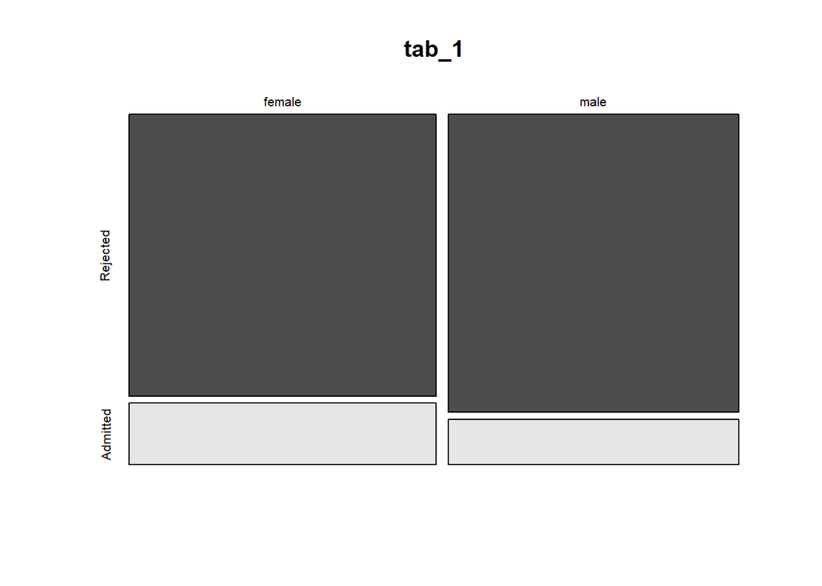

```r
tab_1 <- table(perform_1[perform_1$test.preparation.course == "completed",]$gender, perform_1[perform_1$test.preparation.course == "completed",]$Admit)
colnames(tab_1) <- c("Rejected", "Admitted")

tab_2 <- table(perform_1[perform_1$test.preparation.course == "none",]$gender, perform_1[perform_1$test.preparation.course == "none",]$Admit)
colnames(tab_2) <- c("Rejected", "Admitted")

mosaicplot(tab_1, color = T)
```

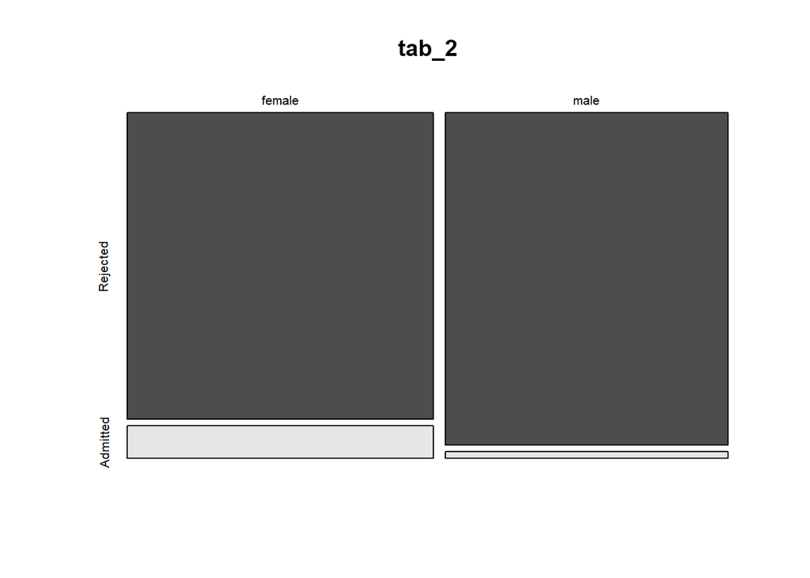

```r
mosaicplot(tab_2, color = T)
```

## d.

시험준비정도, 성별, 합격여부를 모두 고려하여 모자이크 플랏을 그리고 특이점이 발견되지 않는지 논하시오.

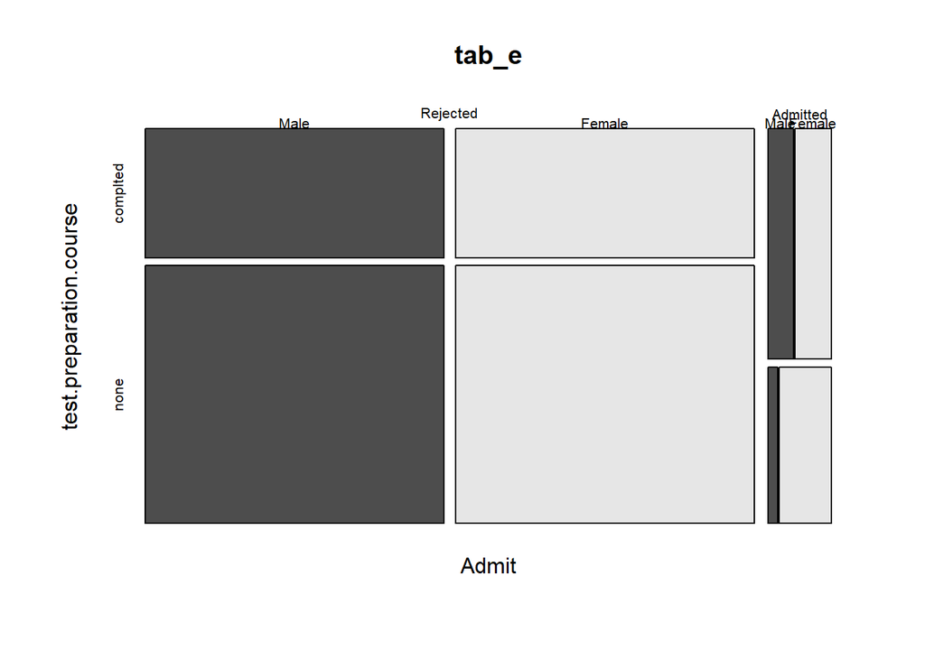

```r
idx_m <- perform_1$gender=="male"
idx_f <- perform_1$gender=="female"
tab_m <- table('test.preparation.course' = perform_1[idx_m, ]$test.preparation.course, "Admit" = perform_1[idx_m, ]$Admit)
tab_f <- table('test.preparation.course' = perform_1[idx_f, ]$test.preparation.course, "Admit" =  perform_1[idx_f, ]$Admit)
column.names <- c("Rejected", "Admitted")
row.names <- c("complted", "none")
matrix.names <- c("Male", "Female")
tab_e <- array(data = c(tab_m, tab_f), dim = c(2,2,2), dimnames = list("test.preparation.course" = row.names, "Admit" = column.names, "gender" = matrix.names))


mosaicplot(~  Admit + test.preparation.course + gender , data = tab_e , off = 2, color = T)
```